# Le partage de la valeur ajoutée

Séminaire *lunch* de 11h de l’OFCE

Xavier Timbeau

xavier.timbeau@sciencespo.fr

[OFCE, Sciences Po Paris](http://www.ofce.fr)

lundi 17 novembre 2025

# Une part des salaires élevée en France en 2025

Une part des salaires élevée en France en 2025

Définitions

Valeur ajoutée nette ou brute

Correction pour les non salariés

Branches marchandes hors immobilier

La question de l’immobilier : optimisation fiscale ?

Annexes

## Pourquoi s’intéresser au partage de la valeur ajoutée ?

- Un problème essentiellement de mesure
- Une application directe à la question salariale
  - Quelle marge de manoeuvre pour revaloriser le travail ?
  - Quel rapport salarial aujourd’hui ?
  - Quel rendement du capital ?
- Un principe : la comptabilité nationale fournit une information, comment et jusqu’où l’utiliser ?
  - Les notions et les méthodes et de la CN sont homogènes d’un pays à l’autre et dans le temps, on peut donc comparer dans l’espace et dans le temps

## La part des salaires est très élevée en France en 2025

[output not shown]

## Ce résultat contraste avec des résultats antérieurs

Depuis Cotis (2009) le consensus est que le partage de la valeur ajoutée est plutôt stable en France – après une période particulière où il a été élevé

Récemment Cette et al. (2019), Pak et al. (2019) et Gendre et Thommen (2025) convergent vers le diagnostic de stabilité.

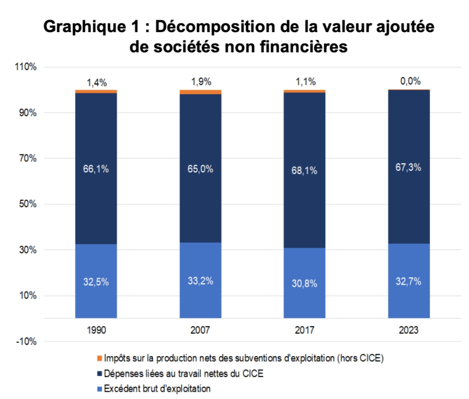

Gendre et Thommen (2025)

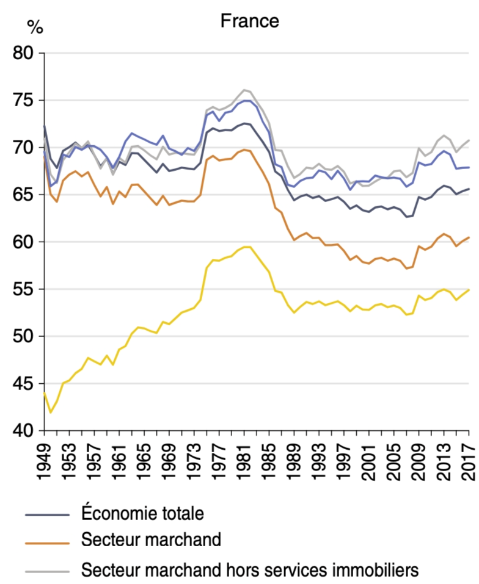

Cette et al. (2019)

## Un rendement du capital productif (très) bas en France

[output not shown]

# Définitions

Une part des salaires élevée en France en 2025

Définitions

Valeur ajoutée nette ou brute

Correction pour les non salariés

Branches marchandes hors immobilier

La question de l’immobilier : optimisation fiscale ?

Annexes

## Part des salaires

$$s_{net, n.s., -LOPQ} = \frac{\sum_{b\in{TT-LOPQ}}{D1_b*(1+ns_b/sal_b)}}{\sum_{b\in{TT-LOPQ}}{B1G_b - P51C_b - (D29_b-D39_b)}}$$

$D1$ est la rémunération des salariés (incluant salaires nets, primes, cotisations employé et employeur)

$B1G$ est la valeur ajoutée brute

$P51C$ la consommation de capital fixe

$ns$ et $sal$ sont soit les effectifs soit les revenus mixtes nets ($B3N$) des non salariés et salariés

$D29$ sont les impôts de production, $D39$ les subventions à la production

Toutes les grandeurs sont en **euros courants**

## Rendement du capital productif

$$\begin{aligned}
\Pi_{\bar{is}} & = B1G - P51C - D1 - (D29-D39) = B2N \\
\Pi_{{is}} & = B1G - P51C - D1 - (D29-D39) - D5 = B2N-D5
\end{aligned}$$

$$\begin{aligned}
r_{productif} & = \frac{\Pi}{N1N+[N2N]} \\
r_{financier} & = \frac{\Pi}{F51+F52+BF90}
\end{aligned}$$

$N1N$ sont les actifs non financiers produits,

$N2N$ les actifs non financiers non produits (ressources naturelles, terre) – non disponible pour bcp de pays

$F51$ Equity (actions), $F52$ Investment fund shares/units, $BF90$ valeur nette rédiduelle

# Valeur ajoutée nette ou brute

Une part des salaires élevée en France en 2025

Définitions

Valeur ajoutée nette ou brute

Correction pour les non salariés

Branches marchandes hors immobilier

La question de l’immobilier : optimisation fiscale ?

Annexes

## Nette plutôt que brute – CCF sur VAN

[output not shown]

La consommation de capital fixe est la quantité de capital « consommée » pendant le processus de production.

Elle est evaluée par des tables de mortalité par classe d’actifs.

## Nette plutôt que brute – CCF sur actifs

[output not shown]

En France, la CCF est particulièrement élevée (21.1% de la VAN en France contre 16.5% en Allemagne).

Actifs sur VAB : Allemagne : 1,65 ; France 1,33

Pourquoi ?

- Structure de l’économie
- Nature de l’investissement

## Nette plutôt que brute

[output not shown]

# Correction pour les non salariés

Une part des salaires élevée en France en 2025

Définitions

Valeur ajoutée nette ou brute

Correction pour les non salariés

Branches marchandes hors immobilier

La question de l’immobilier : optimisation fiscale ?

Annexes

## Les non salariés sont des travailleurs comme les autres

Surout la valeur ajoutée des branches intègre l’activité des non salariés.

En France, en 1970, le revenu des non salariés est égal à celui des salariés des branches marchandes

On traite les non salariés en leur attribuant un salaire égal à celui des salariés de la branche. C’es la méthode « effectif » Askenazy et al. (2012)

Mais :

- un ouvrier agricole n’est pas un « agriculteur », le ratio n’est pas le même aujourd’hui qu’hier
- les plateformes développent de nouvelles formes de non salariés, peu payés, au heures malconnues, avec double compte possible

Une autre méthode est possible : le revenu mixte

- la CN définit depuis (longtemps base 2020, base 2014, ESA 2010, 1995) le revenu mixte (B3G). La base 2020 diffuse B3G au niveau des branches.

## Le revenu des non salariés

[output not shown]

## Correction effectifs

[output not shown]

## Correction revenu mixte

[output not shown]

## Rendement du capital « effectif vs revenu mixte »

[output not shown]

# Branches marchandes hors immobilier

Une part des salaires élevée en France en 2025

Définitions

Valeur ajoutée nette ou brute

Correction pour les non salariés

Branches marchandes hors immobilier

La question de l’immobilier : optimisation fiscale ?

Annexes

## Les services immobiliers : résidentiel et aux entreprises

Les services immobiliers (L) sont décomposés en 2 grandes catégories :

Le partage de la valeur ajoutée pour les services immobilier résidentiel n’est pas pertinent Pak et al. (2019) ; celui des services aux entreprises est ennuyeux

## Champ marchand vs hors immobilier

[output not shown]

# La question de l’immobilier : optimisation fiscale ?

Une part des salaires élevée en France en 2025

Définitions

Valeur ajoutée nette ou brute

Correction pour les non salariés

Branches marchandes hors immobilier

La question de l’immobilier : optimisation fiscale ?

Annexes

## La consommation intermétiare d’immobilier

[output not shown]

## Impact sur le rendement

[output not shown]

# Annexes

Une part des salaires élevée en France en 2025

Définitions

Valeur ajoutée nette ou brute

Correction pour les non salariés

Branches marchandes hors immobilier

La question de l’immobilier : optimisation fiscale ?

Annexes

## Changement de structure des branches

[output not shown]

## France 1949-2024

[output not shown]

## Rendement du capital France 1978-2024

[output not shown]

## Reproductibilité

- Le document de travail OFCE 2025-23 (https://xtimbeau.github.io/travail)[https://xtimbeau.github.io/travail] est entièrement **exécutable** : le code n’est pas là uniquement pour le résultat mais aussi pour documenter les étapes qui conduisent au résultat, des données publiques au document publié.
- Le code est accessible à github.com/xtimbeau/travail, un dépôt en lecture seule
  - Structuré en un `.qmd` avec le texte et les graphiques et des fichiers `R` dans le dossier `R`
  - Chaque fichier R accède à une source (téléchargement des données) et opére des transformations
  - `source_data()` permet de mettre en cache les téléchargements et assure le bon fonctionnement du dépôt sans recharger les données (dans le dossier `.sourcoise`)
  - la mise à jour peut modifier les graphiques, voire si changement du format déclencher une erreur
  - `renv` enregistre les packages et leurs versions (y compris ceux qui ne sont pas sur CRAN)
  - Un `README.md` documente l’entrée dans le code (affiché sur github.com)
- Le pdf (mis en page) est produit à partir du même qmd que le html – mêmes données, même texte, il est sur le site de l’OFCE
- Cela permet :
  - *La transparence* : tous les calculs sont explicites, pas d’ambiguïté. Si il y a des erreurs, elles peuvent être identifiées et corrigées
  - *La persistance* : les données peuvent être mises à jour, les graphiques ou les tableaux actualisés
  - *La descendance* : le code peut être réutilisé – par soi même, par d’autres – pour d’autres travaux

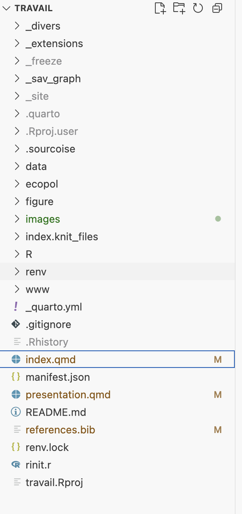

## Références

Askenazy, Philippe, Gilbert Cette, et Arnaud Sylvain. 2012. « Le partage de la valeur ajoutée ». *Repères*, publication en ligne anticipée, septembre 1. https://doi.org/10.3917/dec.asken.2012.01.

Cette, Gilbert, Lorraine Koehl, et Thomas Philippon. 2019. « La part du travail sur le long terme : un déclin ? » *Economie et Statistique / Economics and Statistics*, nᵒ 510‑511‑512 (décembre): 35‑51. https://doi.org/10.24187/ecostat.2019.510t.1993.

Cotis, Jean-Philippe. 2009. *Partage de la valeur ajoutée, partage des profits et écarts de rémunérations en France*. Rapport pour la Présidence de la République Française. https://www.vie-publique.fr/rapport/30455-partage-valeur-ajoutee-partage-profits-et-ecarts-de-remuneration.

Gendre, Charles, et Yann Thommen. 2025. « Le partage de la richesse produite en France entre le travail et le capital ». *Trésor-Éco*, nᵒ 363 (mai). https://www.tresor.economie.gouv.fr/Articles/b72e151f-ac09-47e6-92eb-30657fce5e46/files/9a8f51d9-a060-4547-8852-b630858d7565.

Pak, Mathilde, Pierre-Alain Pionnier, et Cyrille Schwellnus. 2019. « La part du travail sur le long terme : un déclin ? » *Economie et Statistique / Economics and Statistics*, nᵒ 510‑511‑512 (décembre): 17‑34. https://doi.org/10.24187/ecostat.2019.510t.1993.

Timbeau, Xavier. 2002. « Le partage de la valeur ajoutée en France ». *Revue de l’OFCE* 80 (1): 63. https://doi.org/10.3917/reof.080.0063.